# Лабораторная работа № 3

Настройка прав доступа

Павличенко Родион Андреевич

1132246838@pfur.ru

Российский университет дружбы народов

2025-08-09

# Информация

## Докладчик

- Павличенко Родион Андреевич
- Cтудент
- Группа НПИбд-02-24
- Российский университет дружбы народов им. П. Лумумбы
- 1132246838@pfur.ru

# Выполнение лабораторной работы

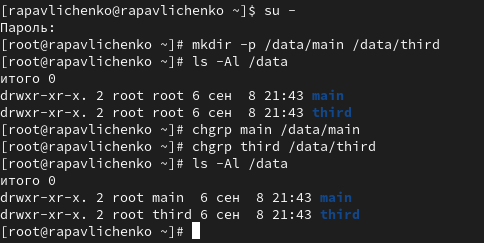

Рисунок 1: Работа с каталогами

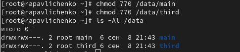

Рисунок 2: Настройка прав доступа

## Перешли под учётную запись пользователя bob. Под пользователем bob перешли в каталог /data/main и создали файл emptyfile в этом каталоге. Файл emptyfile имеет владельца bob, группа bob является основной для нашего пользователя, поэтому и является владельцем

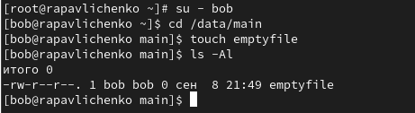

Рисунок 3: Работа с файлом emptyfile

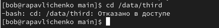

## Открыли новый терминал под пользователем alice, перешли в каталог /data/main, создали два файла, владельцем которых является alice

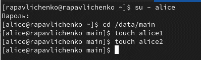

Рисунок 5: Создание файлов в ailce

## В другом терминале перейдите под учётную запись пользователя bob, перешли в каталог /data/main, и в этом каталоге ввели: ls -l. Удалили файлы, принадлежащие пользователю alice, убедились, что файлы были удалены пользователем bob

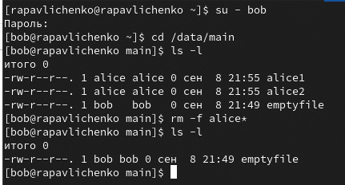

Рисунок 6: Работа с каталогом bob и файлами

## Создали два файла, которые принадлежат пользователю bob

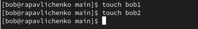

Рисунок 7: Создание файлов

## В терминале под пользователем root установили для каталога /data/main бит идентификатора группы, а также stiky-бит для разделяемого (общего) каталога группы

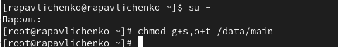

Рисунок 8: Установка бита индентификатора группы

## В терминале под пользователем alice создали в каталоге /data/main файлы alice3 и alice4, в терминале под пользователем alice попробовали удалить файлы, принадлежащие пользователю bob

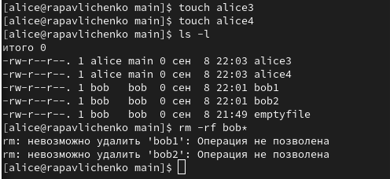

Рисунок 9: Создание файлов в alice

## Открыли терминал с учётной записью root, установили права на чтение и выполнение в каталоге /data/main для группы third и права на чтение и выполнение для группы main в каталоге /data/third, использовали команду getfacl, чтобы убедиться в правильности установки разрешений

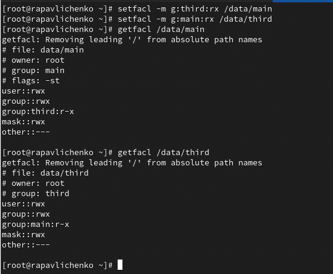

Рисунок 10: Установка права на чтение и выполнение в каталоге /data/main

## Создали новый файл с именем newfile1 в каталоге /data/main, использовали getfacl /data/main/newfile1 для проверки текущих назначений полномочий, у user права на чтение и запись, у группы только на чтение, у остальных также только на чтение

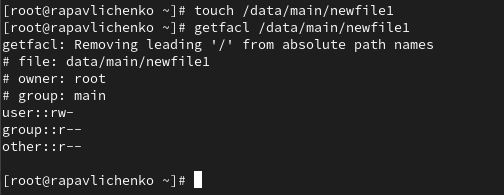

Рисунок 11: Работа с файлов newfile1

## Выполните аналогичные действия для каталога /data/third, файла принадлежит user, он имеет права доступа на чтение и запись, группа только на чтение, остальные только на чтение

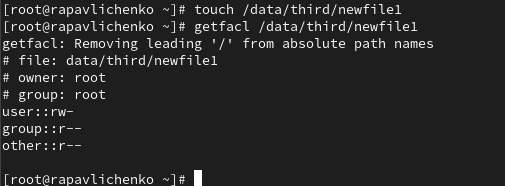

Рисунок 12: Выполнение аналогичных действий для каталога /data/third

## Установили ACL по умолчанию для каталога /data/main, добавили ACL по умолчанию для каталога /data/third, убедились, что настройки ACL работают, добавив новый файл в каталог /data/main, использовали getfacl /data/main/newfile2 для проверки текущих назначений полномочий. Выполнили аналогичные действия для каталога /data/third

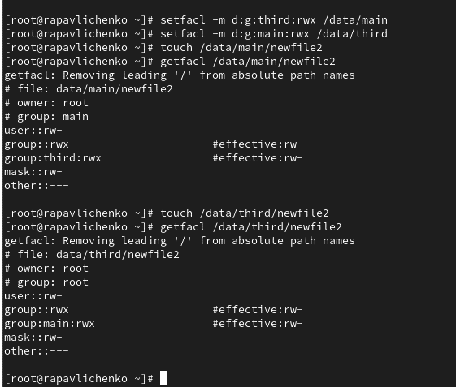

Рисунок 13: Установка ACL

## Для проверки полномочий группы third в каталоге /data/third вошли в другом терминале под учётной записью члена группы third, проверили операции с файлами: rm /data/main/newfile1 rm /data/main/newfile2 Проверили возможно ли осуществить запись в файл. Не смогли удалить файл newfile 2, но смогли в него записать текс

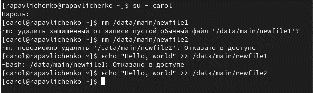

Рисунок 14: Попытка удаления файлов